Bruno Cossaro - Master Data Science M1

# Physical Fundamentals for the Case of Nonlinear Deformations (Mooney-Rivlin)

The **hyperelastic** behavior is based on the idea that the material possesses a **strain energy** function ( W ), from which the stresses are derived. In the **Mooney-Rivlin** model, it is assumed that:

$$ W = C_1 \,(I_1 - 3) \;+\; C_2 \,(I_2 - 3), $$

where:

- $( C_1, C_2 )$ are parameters experimentally determined for the material.
- $( I_1, I_2 )$ are the **first and second invariants** of the **right Cauchy-Green tensor**, $\mathbf{C} = \mathbf{F}^\top \mathbf{F}$

The **deformation gradient tensor** $\mathbf{F}$ is expressed as:

$$ \mathbf{F} = \mathbf{I} + \nabla_X \mathbf{u}, $$

where $\mathbf{u}(X)$ represents the **displacement field** at each point $X$ in the reference configuration. From $\mathbf{F}$:, the **right Cauchy-Green tensor** is derived:

$$ \mathbf{C} = \mathbf{F}^\top \mathbf{F}. $$

The **stress tensor** used in the equilibrium formulation in the reference configuration is the **First Piola–Kirchhoff Stress Tensor**, $\mathbf{P}$. This tensor relates to the **Second Piola–Kirchhoff Stress Tensor**, $\mathbf{S}$, through:

$$ \mathbf{P} = \mathbf{F}\,\mathbf{S}. $$

The tensor $\mathbf{S}$ is computed from the derivative of the energy potential with respect to the tensor $\mathbf{C}$:

$$ \mathbf{S} = 2\, \frac{\partial W}{\partial \mathbf{C}}. $$

For the Mooney-Rivlin model, the invariants are defined as:

$$ I_1 = \mathrm{tr}(\mathbf{C}), \quad I_2 = \tfrac12 \bigl[I_1^2 - \mathrm{tr}(\mathbf{C}^2)\bigr]. $$

Under the hypothesis of **equilibrium** without body forces in the reference configuration, the following condition holds:

$$ \nabla_X \cdot \mathbf{P} = \mathbf{0}. $$

The **boundary conditions** can be specified as:

1. **Dirichlet conditions** (imposed displacements) in areas where the structure is clamped or fixed.
2. **Neumann conditions** (imposed tractions or forces) in regions subjected to distributed loads or contact stresses.

[Source 1](https://hal.science/hal-01004686v1/file/2003-Comparaison%20of%20hyperelastic%20models%20for%20rubber-like%20materials-GM%20EV.pdf?utm_source=chatgpt.com)

[Source 2](https://help.febio.org/docs/FEBioTheory-4-1/TM41-Subsection-5.3.1.html?utm_source=chatgpt.com)

[Source 3](https://www.mm.bme.hu/~gyebro/files/ans_help_v182/ans_thry/thy_mat5.html?utm_source=chatgpt.com)

# PINN for Hyperelastic Deformation using the Mooney-Rivlin Model

In this notebook, we use a Physics-Informed Neural Network (PINN) with DeepXDE to solve a boundary value problem for a hyperelastic material modeled using the Mooney-Rivlin equations. The idea is to combine neural networks with physical laws (given by PDEs) so that the solution not only fits data or boundary values but also obeys the underlying physics.

## 1. Neural Network Setup

Our network takes spatial coordinates as inputs: $$ \mathbf{x} = (x, y, z) $$ where every point lies in the 3D domain: $$ \Omega = \{ (x, y, z) \;|\; 0 \leq x \leq L,\; 0 \leq y \leq W,\; 0 \leq z \leq H \} $$ with $$ L = 1.0,\quad W = 1.0,\quad H = 6.0. $$

### Outputs

The network predicts the displacement field at each spatial point: $$ \mathbf{u} = \big( u(x, y, z),\; v(x, y, z),\; w(x, y, z) \big) $$ where:

- $u$ corresponds to displacement in the $x$-direction,
- $v$ in the $y$-direction,
- $w$ in the $z$-direction.

The goal is for the network to learn and approximate these displacements throughout the domain.

## 2. Incorporating the Physics

The key idea of a PINN is to enforce the governing physics (here, the Mooney-Rivlin hyperelastic model) directly in the training process. Here’s how we do it:

### Deriving the PDE Residuals

1. **Computing Strains:**  
   We differentiate the displacement outputs with respect to the spatial coordinates. For example: $ u_x = \frac{\partial u}{\partial x},\quad v_y = \frac{\partial v}{\partial y},\quad \text{etc.} $ These derivatives are used to form components of the Green-Lagrange strain tensor: $ E_{xx} = u_x,\quad E_{xy} = \frac{1}{2}(u_y + v_x), \quad \text{etc.} $
2. **Stress Calculation:**  
   Next, we compute strain invariants: $ I_1 = E_{xx} + E_{yy} + E_{zz},\quad I_2 = E_{xx}E_{yy} + E_{yy}E_{zz} + E_{zz}E_{xx} - E_{xy}^2 - E_{xz}^2 - E_{yz}^2. $ The Mooney-Rivlin model gives us the stress components: $ S_{xx} = 2C_1 + 2C_2(I_1-3),\quad S_{xy} = 2C_2E_{xy},\quad \text{etc.} $ Here, $ C_1 $ and $ C_2 $ are material constants.
3. **Equilibrium Equations:**
   The equilibrium (or conservation) laws require the divergence of the stress tensor to vanish: $$ \nabla \cdot \mathbf{S} = \mathbf{0}. $$ This results in equations like: $$ f_x = \frac{\partial S_{xx}}{\partial x} + \frac{\partial S_{xy}}{\partial y} + \frac{\partial S_{xz}}{\partial z} = 0, $$ and similarly for $ f_y $ and $ f_z $.
   In our code, these residuals $$ [f_x, f_y, f_z] $$ are returned by the `pde` function, and the network is trained to drive these values to zero.

## 3. Loss Function

The total loss for the PINN is a combination of:

1. **PDE Residual Loss:**
   This loss ensures that the solution satisfies the equilibrium equations: $$ \mathcal{L}_{\text{PDE}} = \| f_x \|^2 + \| f_y \|^2 + \| f_z \|^2. $$
2. **Boundary Condition Loss:**  
   We also need the solution to satisfy boundary conditions:
   - **Dirichlet Boundary:** For example, on the fixed face (e.g., $ x = 0 $), we force: $ \mathbf{u}(x=0) = (0,0,0), $ adding a loss term: $$ \mathcal{L}_{\text{Dirichlet}} = \big\| \mathbf{u}(x=0) - (0, 0, 0) \big\|^2. $$
   - **Neumann Boundary:** At the face where force is applied (e.g., $ x = L $), the network must reflect the applied traction: $$ \mathcal{L}_{\text{Neumann}} = \big\| \text{(predicted traction)} - (10.0, 0, 0) \big\|^2. $$

The overall loss is a weighted sum of these components and guides the network to find a solution that respects both the physics and the boundary data.

## 4. Training and Optimization

### Integrating Physics with Data

Unlike standard neural nets that are trained solely on data, our PINN uses the physics (in the form of PDE residuals) as part of the loss. This means we don’t need vast amounts of labeled data – the governing equations help steer the training toward physically plausible solutions.

## 5. Workflow Summary

```python
import deepxde as dde
import numpy as np
import tensorflow as tf
from mpl_toolkits.mplot3d import Axes3D
import matplotlib.pyplot as plt


dde.config.set_default_float("float64")

# Geometry of the problem:

L, W, H = 1.0, 1.0, 6.0  # Length, width, height
geom = dde.geometry.Cuboid(xmin=[0, 0, 0], xmax=[L, W, H])

# Material parameters for the Mooney-Rivlin model
C1 = 1.0  # Mpa First model parameter, example Caucho
C2 = 0.1  # Mpa Second model parameter

def pde(inputs, outputs):
    # Displacement variables
    u = outputs[:, 0:1]  # Displacement in x-direction
    v = outputs[:, 1:2]  # Displacement in y-direction
    w = outputs[:, 2:3]  # Displacement in z-direction

    # Gradients (strains)
    u_x = dde.grad.jacobian(u, inputs, j=0)  # du/dx
    u_y = dde.grad.jacobian(u, inputs, j=1)  # du/dy
    u_z = dde.grad.jacobian(u, inputs, j=2)  # du/dz

    v_x = dde.grad.jacobian(v, inputs, j=0)  # dv/dx
    v_y = dde.grad.jacobian(v, inputs, j=1)  # dv/dy
    v_z = dde.grad.jacobian(v, inputs, j=2)  # dv/dz

    w_x = dde.grad.jacobian(w, inputs, j=0)  # dw/dx
    w_y = dde.grad.jacobian(w, inputs, j=1)  # dw/dy
    w_z = dde.grad.jacobian(w, inputs, j=2)  # dw/dz

    # Green-Lagrange strain tensor (only symmetric part)
    E_xx = u_x
    E_yy = v_y
    E_zz = w_z
    E_xy = 0.5 * (u_y + v_x)
    E_xz = 0.5 * (u_z + w_x)
    E_yz = 0.5 * (v_z + w_y)

    # Invariants of the strain tensor
    I1 = E_xx + E_yy + E_zz
    I2 = E_xx * E_yy + E_yy * E_zz + E_zz * E_xx - E_xy**2 - E_xz**2 - E_yz**2

    # Stress tensors (Mooney-Rivlin constitutive model)
    S_xx = 2 * C1 + 2 * C2 * (I1 - 3)
    S_yy = 2 * C1 + 2 * C2 * (I1 - 3)
    S_zz = 2 * C1 + 2 * C2 * (I1 - 3)
    S_xy = 2 * C2 * E_xy
    S_xz = 2 * C2 * E_xz
    S_yz = 2 * C2 * E_yz

    # Divergence of the stress tensor
    div_S_x = dde.grad.jacobian(S_xx, inputs, j=0) + \
              dde.grad.jacobian(S_xy, inputs, j=1) + \
              dde.grad.jacobian(S_xz, inputs, j=2)
    div_S_y = dde.grad.jacobian(S_xy, inputs, j=0) + \
              dde.grad.jacobian(S_yy, inputs, j=1) + \
              dde.grad.jacobian(S_yz, inputs, j=2)
    div_S_z = dde.grad.jacobian(S_xz, inputs, j=0) + \
              dde.grad.jacobian(S_yz, inputs, j=1) + \
              dde.grad.jacobian(S_zz, inputs, j=2)

    # Equilibrium equations
    f_x = div_S_x
    f_y = div_S_y
    f_z = div_S_z

    #I use div(S) instead of div(P) for simplification and not compute FP

    return [f_x, f_y, f_z]


# boundary conditions:

# Fixed boundary at x=0 (zero displacement)
def boundary_fixed(x, on_boundary):
    return on_boundary and np.isclose(x[0], 0)

bc_fixed = dde.DirichletBC(geom, lambda x: [0, 0, 0], boundary_fixed)

# Boundary with applied traction at x=L
def boundary_force(x, on_boundary):
    return on_boundary and np.isclose(x[0], L)

force_value = 10.0
bc_force = dde.NeumannBC(geom, lambda x: [force_value, 0, 0], boundary_force)


#Rubber like sim
```

```
Using backend: pytorch
Other supported backends: tensorflow.compat.v1, tensorflow, jax, paddle.
paddle supports more examples now and is recommended.
```

```
Set the default float type to float64
```

```python
# PINN configuration:

# Modelo PINN con entradas 3D (x, y, z) y salidas 3D (u, v, w), 5 capas ocultas con 100 neuronas
net = dde.maps.FNN([3] + [100] * 5 + [3], "tanh", "Glorot normal")


pde_data = dde.data.PDE(
    geom,
    pde,
    [bc_fixed, bc_force],
    num_domain=10000,
    num_boundary=500,
)

model = dde.Model(pde_data, net)
```

```python
# Training:

model.compile("adam", lr=0.001)
loss_history, train_state = model.train(iterations=5000)
```

```
Compiling model...
'compile' took 0.000216 s

Training model...

0         [4.60e-05, 5.72e-05, 4.82e-06, 1.58e-02, 3.29e+01]    [4.60e-05, 5.72e-05, 4.82e-06, 1.58e-02, 3.29e+01]    []
1000      [4.84e-05, 1.01e-04, 2.26e-05, 4.56e-06, 2.22e+01]    [4.84e-05, 1.01e-04, 2.26e-05, 4.56e-06, 2.22e+01]    []
2000      [3.45e-05, 5.57e-05, 1.05e-05, 6.87e-06, 2.22e+01]    [3.45e-05, 5.57e-05, 1.05e-05, 6.87e-06, 2.22e+01]    []
3000      [1.62e-05, 3.02e-05, 7.14e-06, 6.00e-06, 2.22e+01]    [1.62e-05, 3.02e-05, 7.14e-06, 6.00e-06, 2.22e+01]    []
4000      [6.15e-05, 7.44e-05, 1.17e-05, 1.11e-04, 2.22e+01]    [6.15e-05, 7.44e-05, 1.17e-05, 1.11e-04, 2.22e+01]    []
5000      [1.47e-05, 1.90e-05, 4.12e-06, 2.39e-06, 2.22e+01]    [1.47e-05, 1.90e-05, 4.12e-06, 2.39e-06, 2.22e+01]    []

Best model at step 5000:
  train loss: 2.22e+01
  test loss: 2.22e+01
  test metric: []

'train' took 16937.125843 s
```

[output not shown]

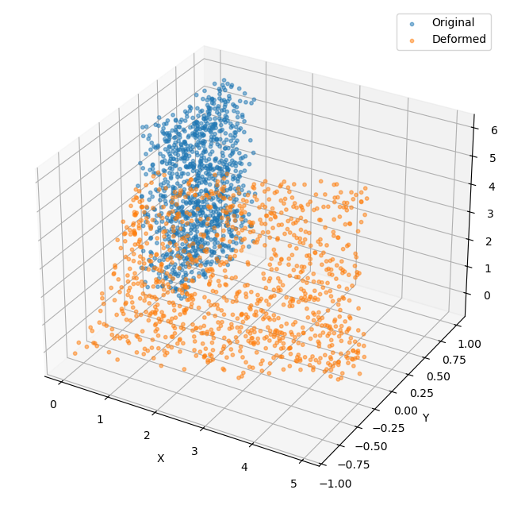

```python
# Generate points in the domain to evaluate the solution
X = geom.random_points(1000)
u_pred = model.predict(X)

# Visualization of the structure before and after deformation
scaling_factor = 1.0  # Scale factor to visually enhance displacements
X_deformed = X + scaling_factor * u_pred

fig = plt.figure(figsize=(10, 8))
ax = fig.add_subplot(111, projection="3d")
ax.scatter(X[:, 0], X[:, 1], X[:, 2], label="Original", alpha=0.5, s=10)  # Points in the original configuration
ax.scatter(X_deformed[:, 0], X_deformed[:, 1], X_deformed[:, 2], label="Deformed", alpha=0.5, s=10)  # Points in the deformed configuration
ax.set_xlabel("X")
ax.set_ylabel("Y")
ax.set_zlabel("Z")
plt.legend()
plt.show()
```

```python
print("First 5 predicted displacements (u_pred):\n", u_pred[:5])
```

```
First 5 predicted displacements (u_pred):
 [[ 1.906205   -0.79814707 -0.65368846]
 [ 1.84699614 -1.22293963 -0.73032999]
 [ 0.53181505 -0.24202245 -1.12348063]
 [ 1.5173706   0.00762388 -1.26392538]
 [ 0.55788219 -1.65209365 -0.82669083]]
```

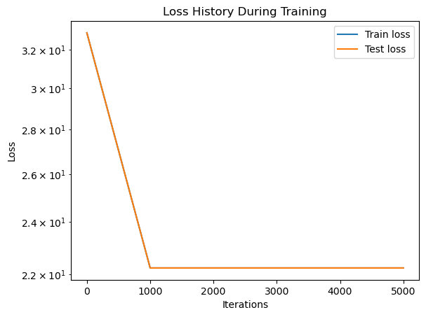

```python
# Plot the loss history during training
dde.utils.plot_loss_history(loss_history)
plt.xlabel("Iterations")
plt.ylabel("Loss")
plt.title("Loss History During Training")
plt.show()
```

```python
print("Displacements u: min =", np.min(u_pred[:, 0]), "max =", np.max(u_pred[:, 0]))
print("Displacements v: min =", np.min(u_pred[:, 1]), "max =", np.max(u_pred[:, 1]))
print("Displacements w: min =", np.min(u_pred[:, 2]), "max =", np.max(u_pred[:, 2]))
```

[output not shown]

```python
# Normalize coord in [0, 1]
X_normalized = X_mesh / [L, W, H]


u_pred = model.predict(X_normalized)
```

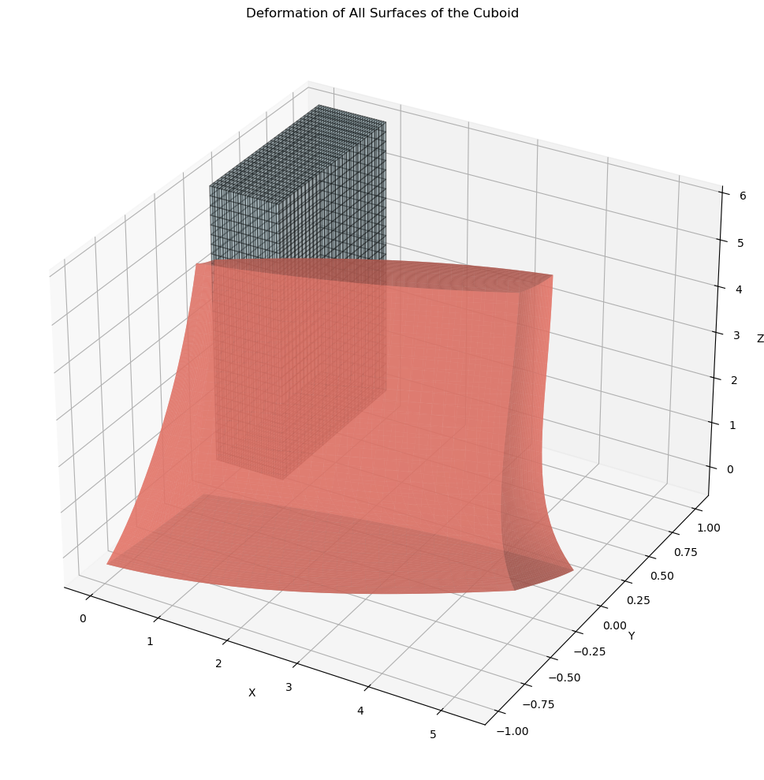

```python
# function to generate grid on a face:

def create_face_grid(face, n1=50, n2=50):
    """
    Create a grid of points on a face of the cuboid.
    'face' is one of:
      'x0', 'xL', 'y0', 'yW', 'z0', 'zH'
    """
    if face == "x0":
        # Face at x = 0, vary y and z.
        y = np.linspace(0, W, n1)
        z = np.linspace(0, H, n2)
        Y, Z = np.meshgrid(y, z)
        X = np.zeros_like(Y)
        return np.stack([X.flatten(), Y.flatten(), Z.flatten()], axis=1), (X, Y, Z)
    elif face == "xL":
        # Face at x = L, vary y and z.
        y = np.linspace(0, W, n1)
        z = np.linspace(0, H, n2)
        Y, Z = np.meshgrid(y, z)
        X = L * np.ones_like(Y)
        return np.stack([X.flatten(), Y.flatten(), Z.flatten()], axis=1), (X, Y, Z)
    elif face == "y0":
        # Face at y = 0, vary x and z.
        x = np.linspace(0, L, n1)
        z = np.linspace(0, H, n2)
        X, Z = np.meshgrid(x, z)
        Y = np.zeros_like(X)
        return np.stack([X.flatten(), Y.flatten(), Z.flatten()], axis=1), (X, Y, Z)
    elif face == "yW":
        # Face at y = W, vary x and z.
        x = np.linspace(0, L, n1)
        z = np.linspace(0, H, n2)
        X, Z = np.meshgrid(x, z)
        Y = W * np.ones_like(X)
        return np.stack([X.flatten(), Y.flatten(), Z.flatten()], axis=1), (X, Y, Z)
    elif face == "z0":
        # Face at z = 0, vary x and y.
        x = np.linspace(0, L, n1)
        y = np.linspace(0, W, n2)
        X, Y = np.meshgrid(x, y)
        Z = np.zeros_like(X)
        return np.stack([X.flatten(), Y.flatten(), Z.flatten()], axis=1), (X, Y, Z)
    elif face == "zH":
        # Face at z = H, vary x and y.
        x = np.linspace(0, L, n1)
        y = np.linspace(0, W, n2)
        X, Y = np.meshgrid(x, y)
        Z = H * np.ones_like(X)
        return np.stack([X.flatten(), Y.flatten(), Z.flatten()], axis=1), (X, Y, Z)
    else:
        raise ValueError("Unknown face.")

# List of faces to visualize
faces = ["x0", "xL", "y0", "yW", "z0", "zH"]
scaling_factor = 1.0


fig = plt.figure(figsize=(12, 10))
ax = fig.add_subplot(111, projection="3d")


orig_color = "lightblue"
def_color = "salmon"

for face in faces:
    # Create the grid for the current face
    points, (X_orig, Y_orig, Z_orig) = create_face_grid(face, n1=30, n2=30)

    # Predict the displacements on these points
    u_pred = model.predict(points)

    # Compute deformed positions
    points_deformed = points + scaling_factor * u_pred
    X_def = points_deformed[:, 0].reshape(X_orig.shape)
    Y_def = points_deformed[:, 1].reshape(Y_orig.shape)
    Z_def = points_deformed[:, 2].reshape(Z_orig.shape)

    # Plot the original surface
    ax.plot_surface(X_orig, Y_orig, Z_orig, color=orig_color, alpha=0.3, edgecolor="k", rstride=1, cstride=1)

    # Plot the deformed surface
    ax.plot_surface(X_def, Y_def, Z_def, color=def_color, alpha=0.7, edgecolor="none")


ax.set_xlabel("X")
ax.set_ylabel("Y")
ax.set_zlabel("Z")
ax.set_title("Deformation of All Surfaces of the Cuboid")

plt.tight_layout()
plt.show()
```